# ARIMA

```python
import pandas as pd
import numpy as np          # For mathematical calculations
import matplotlib.pyplot as plt  # For plotting graphs
from datetime import datetime    # To access datetime
from pandas import Series        # To work on series
%matplotlib inline
import warnings

from pandas import DataFrame
from matplotlib import pyplot
from sklearn.metrics import mean_squared_error,mean_absolute_error
from statsmodels.tsa.arima_model import ARIMA
from math import sqrt


from statsmodels.tsa.stattools import adfuller
from matplotlib.pylab import rcParams

from statsmodels.tsa.stattools import acf, pacf
from statsmodels.graphics.tsaplots import plot_acf,plot_pacf
from statsmodels.tsa.statespace.sarimax import SARIMAX
```

## Helper Functions

```python
def model_quality(truth,predictions,model):
    print("__"*50,"\n")
    print('The RMSE of the '+str(model)+' is',sqrt(mean_squared_error(truth,predictions)))
    print("__"*50,"\n")

    print('The MSE of the '+str(model)+'  is',mean_squared_error(truth,predictions))

    print("__"*50,"\n")
    print('The MAE of the '+str(model)+'  is',mean_absolute_error(truth,predictions))


    print("__"*50,"\n")

    print("__"*50,"\n")
    print("Sum of Original Sales for next 28 days: ",sum(truth))
    print("Sum of Predicted Sales for next 28 days: ",sum(predictions))
    print('The difference between model original and predictions values of the '+str(model)+' is',sum(truth) - sum(predictions))


    print("__"*50,"\n")
```

```python
def check_prediction_diff(predict_diff, given_set):
    predict_diff= predict_diff.cumsum().shift().fillna(0)
    predict_base = pd.Series(np.ones(given_set.shape[0]) * np.log(given_set['volume_sold'])[0], index = given_set.index)
    predict_log = predict_base.add(predict_diff,fill_value=0)
    predict = np.exp(predict_log)

    plt.plot(given_set['volume_sold'], label = "Given set")
    plt.plot(predict, color = 'red', label = "Predict")
    plt.legend(loc= 'best')
    plt.title('RMSE: %.4f'% (np.sqrt(np.dot(predict, given_set['volume_sold']))/given_set.shape[0]))
    plt.show()
```

```python
def weekend(row):
    if row.dayofweek == 5 or row.dayofweek == 6:
        return 1
    else:
        return 0
```

```python
data=pd.read_csv("data.csv")
data_original=data.copy()
```

```python
data['volume_sold']=data['volume_sold'].abs()
data['revenue']=data['revenue'].abs()
data['cost']=data['cost'].abs()
data['vdm1']=data['vdm1'].abs()
data['vwm1']=data['vwm1'].abs()
data['vmm1']=data['vmm1'].abs()
data['rdm1']=data['rdm1'].abs()
data['rwm1']=data['rwm1'].abs()
data['rmm1']=data['rmm1'].abs()
data['cdm1']=data['cdm1'].abs()
data['cwm1']=data['cwm1'].abs()
data['cmm1']=data['cmm1'].abs()
data['stock_level']=data['stock_level'].abs()
```

```python
data['calendar_date'] = pd.to_datetime(data.calendar_date,format='%m/%d/%Y')
```

```python
data['year']=data.calendar_date.dt.year
data['month']=data.calendar_date.dt.month
data['day']=data.calendar_date.dt.day
```

```python
data['day of week']=data['calendar_date'].dt.dayofweek
```

```python
temp2 = data['calendar_date'].apply(weekend)
data['weekend']=temp2
```

```python
data.index = data['calendar_date']
```

```python
data.sort_index(inplace=True)
```

```python
products=list(data['product_id'].unique())
```

## Data Split

```python
Train=data.ix['2017-01-01':'2017-10-31']
valid=data.ix['2017-11-01':'2017-11-28']
```

### ARIMA model

ARIMA stands for Auto Regression Integrated Moving Average. It is specified by three ordered parameters (p,d,q).

- Here p is the order of the autoregressive model(number of time lags)
- d is the degree of differencing(number of times the data have had past values subtracted)
- q is the order of moving average model. We will discuss more about these parameters in next section.

The ARIMA forecasting for a stationary time series is nothing but a linear (like a linear regression) equation.

What is a stationary time series?

There are three basic criterion for a series to be classified as stationary series :

- The mean of the time series should not be a function of time. It should be constant.
- The variance of the time series should not be a function of time.
- The covariance of the ith term and the (i+m)th term should not be a function of time.

Why do we have to make the time series stationary?

We make the series stationary to make the variables independent. Variables can be dependent in various ways, but can only be independent in one way. So, we will get more information when they are independent. Hence the time series must be stationary.

If the time series is not stationary, firstly we have to make it stationary. For doing so, we need to remove the trend and seasonality from the data.

### Parameter tuning for ARIMA model

First of all we have to make sure that the time series is stationary. If the series is not stationary, we will make it stationary.

##### Stationarity Check

We use Dickey Fuller test to check the stationarity of the series.

- The intuition behind this test is that it determines how strongly a time series is defined by a trend.
- The null hypothesis of the test is that time series is not stationary (has some time-dependent structure).
- The alternate hypothesis (rejecting the null hypothesis) is that the time series is stationary.
- The test results comprise of a Test Statistic and some Critical Values for difference confidence levels. If the ‘Test Statistic’ is less than the ‘Critical Value’, we can reject the null hypothesis and say that the series is stationary.

We interpret this result using the Test Statistics and critical value. If the Test Statistics is smaller than critical value, it suggests we reject the null hypothesis (stationary), otherwise a greater Test Statistics suggests we accept the null hypothesis (non-stationary).

```python
def test_stationarity(timeseries):
    #Determing rolling statistics
    rolmean = timeseries.rolling(7).mean()
    rolstd = timeseries.rolling(7).std()
        #Plot rolling statistics:
    orig = plt.plot(timeseries, color='blue',label='Original')
    mean = plt.plot(rolmean, color='red', label='Rolling Mean')
    std = plt.plot(rolstd, color='black', label = 'Rolling Std')
    plt.legend(loc='best')
    plt.title('Rolling Mean & Standard Deviation')
    plt.show(block=False)
        #Perform Dickey-Fuller test:
    print ('Results of Dickey-Fuller Test:')
    dftest = adfuller(timeseries, autolag='AIC')
    dfoutput = pd.Series(dftest[0:4], index=['Test Statistic','p-value','#Lags Used','Number of Observations Used'])

    for key,value in dftest[4].items():
        dfoutput['Critical Value (%s)'%key] = value
    print (dfoutput)
```

```
_______________________________________
Item: 13701
```

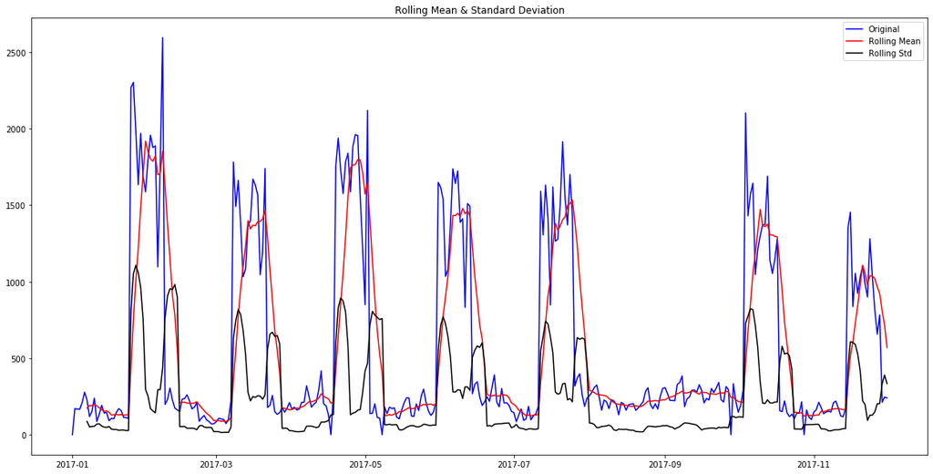

```
Results of Dickey-Fuller Test:
Test Statistic                -5.785173e+00
p-value                        5.018897e-07
#Lags Used                     1.400000e+01
Number of Observations Used    3.200000e+02
Critical Value (1%)           -3.450952e+00
Critical Value (5%)           -2.870615e+00
Critical Value (10%)          -2.571605e+00
dtype: float64
_______________________________________
Item: 26104
```

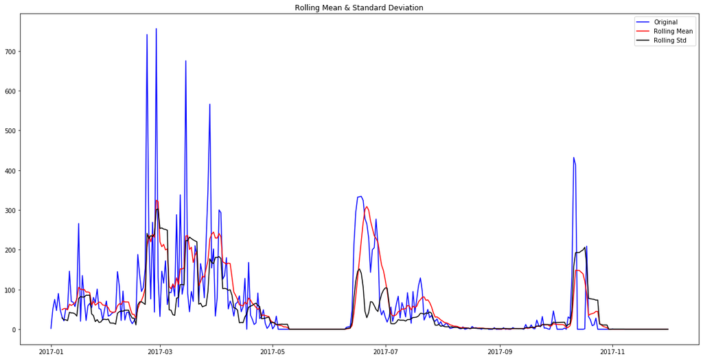

```
Results of Dickey-Fuller Test:
Test Statistic                  -2.708058
p-value                          0.072654
#Lags Used                      16.000000
Number of Observations Used    318.000000
Critical Value (1%)             -3.451082
Critical Value (5%)             -2.870672
Critical Value (10%)            -2.571636
dtype: float64
_______________________________________
Item: 158737
```

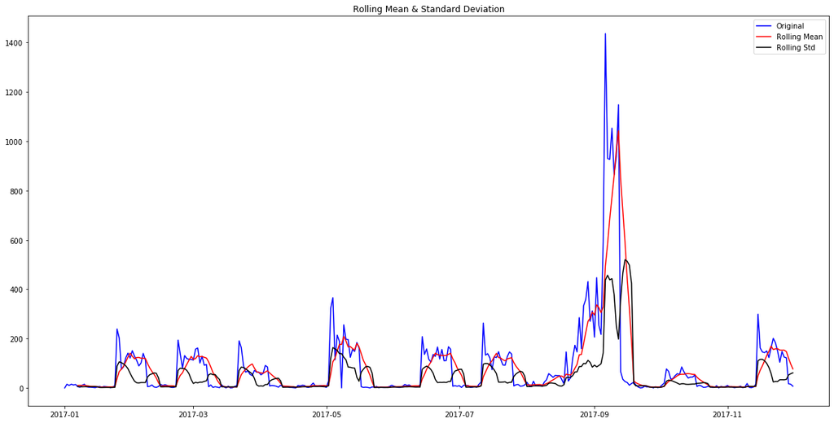

```
Results of Dickey-Fuller Test:
Test Statistic                  -3.849866
p-value                          0.002436
#Lags Used                      10.000000
Number of Observations Used    324.000000
Critical Value (1%)             -3.450695
Critical Value (5%)             -2.870502
Critical Value (10%)            -2.571545
dtype: float64
_______________________________________
Item: 158105
```

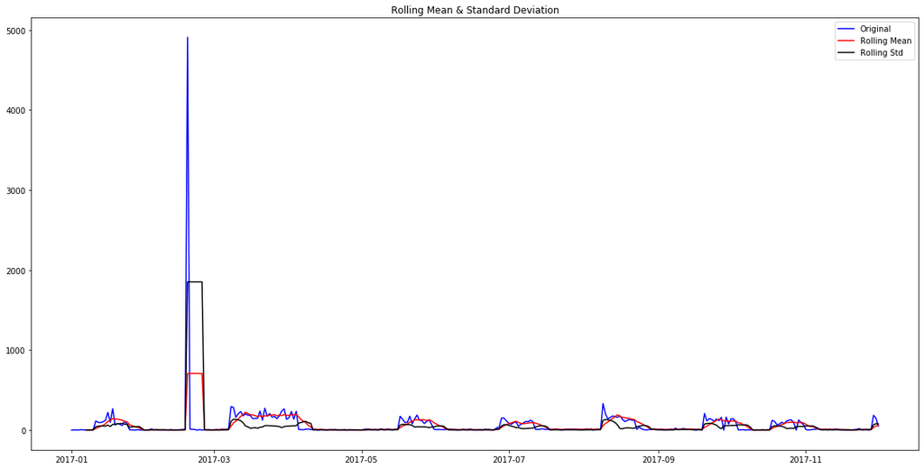

```
Results of Dickey-Fuller Test:
Test Statistic                -1.765210e+01
p-value                        3.716009e-30
#Lags Used                     0.000000e+00
Number of Observations Used    3.340000e+02
Critical Value (1%)           -3.450081e+00
Critical Value (5%)           -2.870233e+00
Critical Value (10%)          -2.571401e+00
dtype: float64
```

```python
for i in range(len(products)):

    print("_______________________________________")
    print("Item: "+str(products[i]))

    data_df=data[data['product_id']==products[i]]
    rcParams['figure.figsize'] = 20,10
    test_stationarity(data_df['volume_sold'])
```

However, let's focus on item 1307 series which is stationary.

##### Nevertheless, log transform and differencing (1,2,... times) can lead to stationary time series

## Forecasting the time series using ARIMA

First of all we will fit the ARIMA model on our time series for that we have to find the optimized values for the p,d,q parameters.

To find the optimized values of these parameters, we will use ACF(Autocorrelation Function) and PACF(Partial Autocorrelation Function) graph.

ACF is a measure of the correlation between the TimeSeries with a lagged version of itself.

PACF measures the correlation between the TimeSeries with a lagged version of itself but after eliminating the variations already explained by the intervening comparisons.

```
_______________________________________
Item: 13701
The autocorrelation plot
```

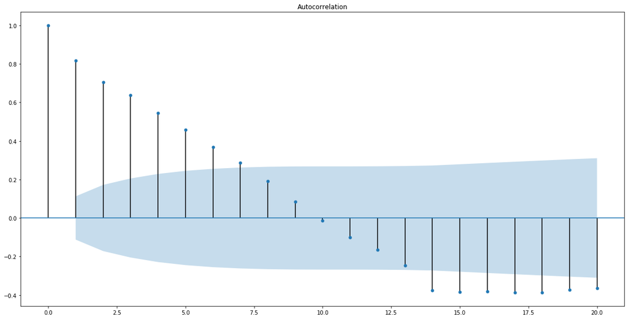

```
_______________________________________
Item: 26104
The autocorrelation plot
```

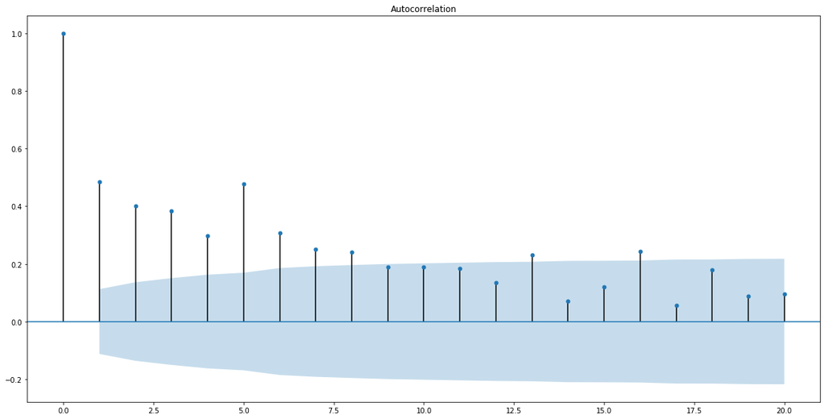

```
_______________________________________
Item: 158737
The autocorrelation plot
```

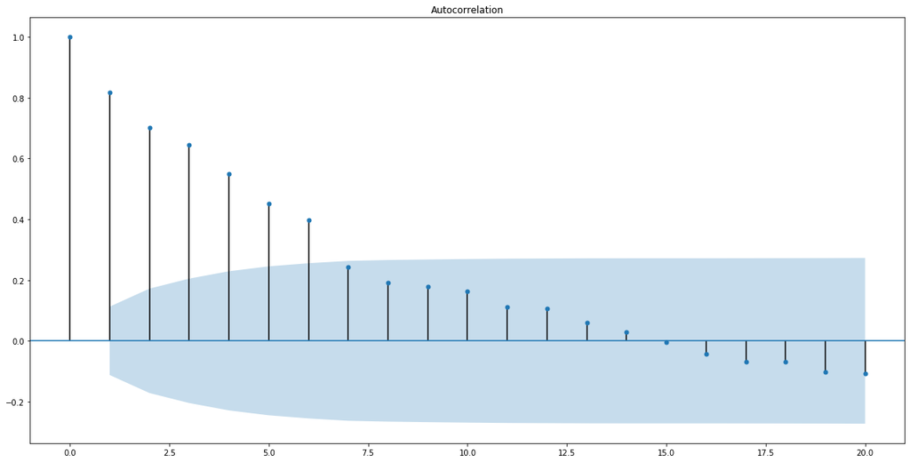

```
_______________________________________
Item: 158105
The autocorrelation plot
```

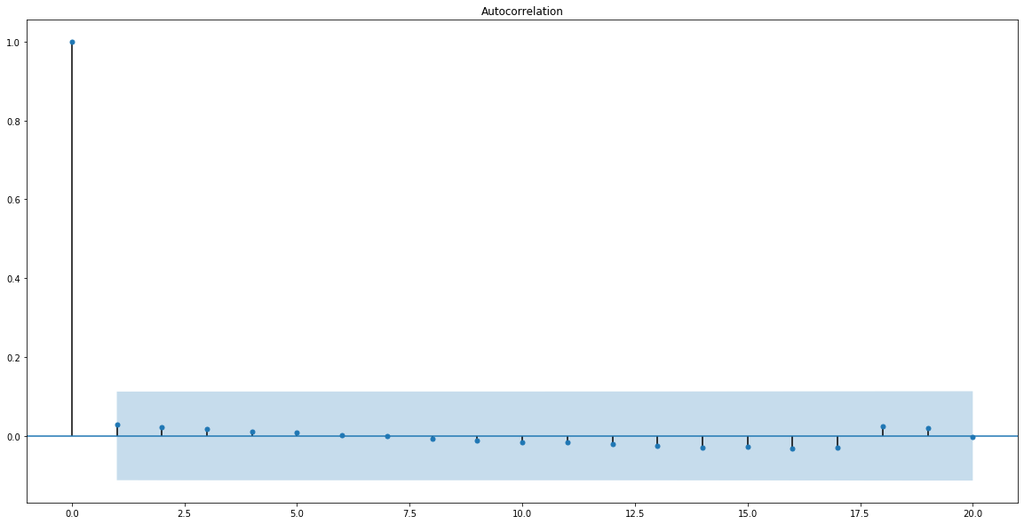

```python
for i in range(len(products)):

    print("_______________________________________")
    print("Item: "+str(products[i]))

    Train_df=Train[Train['product_id']==products[i]]
    valid_df=valid[valid['product_id']==products[i]]
    print("The autocorrelation plot")
    plot_acf(Train_df['volume_sold'], alpha=0.05, lags=20)
    plt.show()
```

```
_______________________________________
Item: 13701
The Partial autocorrelation plot
```

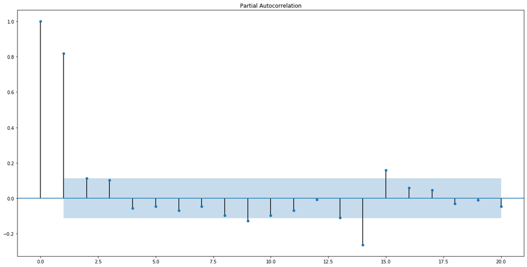

```
_______________________________________
Item: 26104
The Partial autocorrelation plot
```

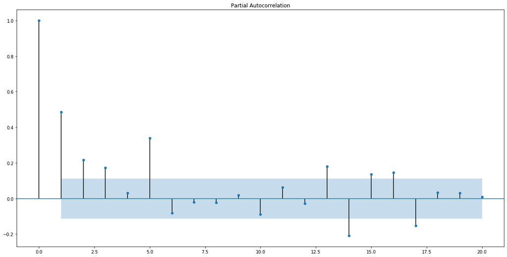

```
_______________________________________
Item: 158737
The Partial autocorrelation plot
```

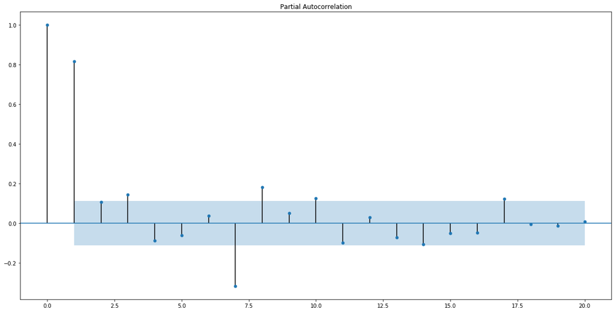

```
_______________________________________
Item: 158105
The Partial autocorrelation plot
```

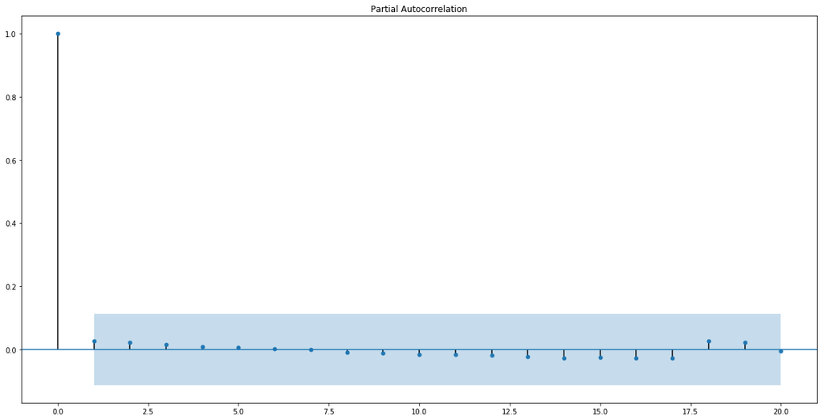

```python
for i in range(len(products)):

    print("_______________________________________")
    print("Item: "+str(products[i]))

    Train_df=Train[Train['product_id']==products[i]]
    valid_df=valid[valid['product_id']==products[i]]
    print("The Partial autocorrelation plot")
    plot_pacf(Train_df['volume_sold'], alpha=0.05, lags=20)
    plt.show()
```

```python
# Fit an AR(1) model to the first simulated data
mod = ARIMA(np.array(Train[Train['product_id']==13701]['volume_sold']).astype(float), order=(1,0,7))
res = mod.fit()

# Print out summary information on the fit
print(res.summary())
```

```
                              ARMA Model Results
==============================================================================
Dep. Variable:                      y   No. Observations:                  304
Model:                     ARMA(1, 7)   Log Likelihood               -2216.436
Method:                       css-mle   S.D. of innovations            353.347
Date:                Sun, 25 Aug 2019   AIC                           4452.871
Time:                        10:46:44   BIC                           4490.041
Sample:                             0   HQIC                          4467.740

==============================================================================
                 coef    std err          z      P>|z|      [0.025      0.975]
------------------------------------------------------------------------------
const        552.7086    154.385      3.580      0.000     250.119     855.298
ar.L1.y        0.8319      0.041     20.475      0.000       0.752       0.912
ma.L1.y       -0.2150      0.069     -3.130      0.002      -0.350      -0.080
ma.L2.y       -0.0732      0.062     -1.181      0.238      -0.195       0.048
ma.L3.y        0.0996      0.058      1.722      0.086      -0.014       0.213
ma.L4.y        0.0094      0.052      0.180      0.857      -0.093       0.112
ma.L5.y        0.0282      0.058      0.485      0.628      -0.086       0.142
ma.L6.y        0.0695      0.064      1.093      0.275      -0.055       0.194
ma.L7.y        0.3927      0.109      3.599      0.000       0.179       0.607
                                    Roots
=============================================================================
                 Real           Imaginary           Modulus         Frequency
-----------------------------------------------------------------------------
AR.1            1.2021           +0.0000j            1.2021            0.0000
MA.1            0.9625           -0.4730j            1.0724           -0.0727
MA.2            0.9625           +0.4730j            1.0724            0.0727
MA.3            0.2919           -1.1053j            1.1432           -0.2089
MA.4            0.2919           +1.1053j            1.1432            0.2089
MA.5           -1.1620           -0.0000j            1.1620           -0.5000
MA.6           -0.7618           -0.9369j            1.2075           -0.3587
MA.7           -0.7618           +0.9369j            1.2075            0.3587
-----------------------------------------------------------------------------
```

### Next 28 days Forecast at a time: Item: 13701

```python
Train_df=Train[Train['product_id']==13701]
valid_df=valid[valid['product_id']==13701]

#Train_log = np.log(Train_df['volume_sold']+1)


model = ARIMA(Train_df['volume_sold'].astype('float32').dropna(), order=(1, 0, 7))  # here the q value is zero since it is just the AR model
results_ARIMA = model.fit(disp=-1)
#train_log_diff = Train_log - Train_log.shift(1)
#plt.plot(train_log_diff.dropna(), label='original')
#plt.plot(results_ARIMA.fittedvalues, color='red', label='predictions')
#plt.legend(loc='best')
#plt.show()

ARIMA_predict=results_ARIMA.predict(start="2017-11-01", end="2017-11-28")

#check_prediction_diff(ARIMA_predict, valid_df)
print("__"*50,"\n")
print('The RMSE of the ARIMA Regression is',sqrt(mean_squared_error(valid_df['volume_sold'].head(28).values,ARIMA_predict.values)))
print("__"*50,"\n")

print('The MSE of the ARIMA Regression is',mean_squared_error(valid_df['volume_sold'].head(28).values,ARIMA_predict.values))

print("__"*50,"\n")
print('The MAE of the ARIMA Regression is',mean_absolute_error(valid_df['volume_sold'].head(28).values,ARIMA_predict.values))


print("__"*50,"\n")

print("Sum of Original Sales for next 28 days: ",valid_df['volume_sold'].head(28).values.sum())
print("Sum of Predicted Sales for next 28 days: ",ARIMA_predict.values.sum())
print('The difference between model original and predictions values of the '+str(model)+' Regression is',valid_df['volume_sold'].head(28).values.sum() - ARIMA_predict.values.sum())
```

```
____________________________________________________________________________________________________

The RMSE of the ARIMA Regression is 420.78860388173433
____________________________________________________________________________________________________

The MSE of the ARIMA Regression is 177063.04915673914
____________________________________________________________________________________________________

The MAE of the ARIMA Regression is 374.4735832428123
____________________________________________________________________________________________________

Sum of Original Sales for next 28 days:  16510
Sum of Predicted Sales for next 28 days:  13757.213933967927
The difference between model original and predictions values of the <statsmodels.tsa.arima_model.ARMA object at 0x7f5f16f2a240> Regression is 2752.786066032073
```

### Next 7 days Forecast at a time: Item: 13701

```python
Train_df=Train[Train['product_id']==13701]
valid_df=valid[valid['product_id']==13701]

#Train_log = np.log(Train_df['volume_sold']+1)


model = ARIMA(Train_df['volume_sold'].astype('float32').dropna(), order=(1, 0, 7))  # here the q value is zero since it is just the AR model
results_ARIMA = model.fit(disp=-1)
#train_log_diff = Train_log - Train_log.shift(1)
#plt.plot(train_log_diff.dropna(), label='original')
#plt.plot(results_ARIMA.fittedvalues, color='red', label='predictions')
#plt.legend(loc='best')
#plt.show()

ARIMA_predict=results_ARIMA.predict(start="2017-11-01", end="2017-11-07")

#check_prediction_diff(ARIMA_predict, valid_df)
print("Original Values: "+str(valid_df['volume_sold'].head(7).values))
print("Predicted Values: "+str(ARIMA_predict.values))


print("__"*50,"\n")
print('The RMSE of the ARIMA Regression is',sqrt(mean_squared_error(valid_df['volume_sold'].head(7).values,ARIMA_predict.values)))
print("__"*50,"\n")

print('The MSE of the ARIMA Regression is',mean_squared_error(valid_df['volume_sold'].head(7).values,ARIMA_predict.values))

print("__"*50,"\n")
print('The MAE of the ARIMA Regression is',mean_absolute_error(valid_df['volume_sold'].head(7).values,ARIMA_predict.values))


print("__"*50,"\n")

print("Sum of Original Sales for next 7 days: ",valid_df['volume_sold'].head(7).values.sum())
print("Sum of Predicted Sales for next 7 days: ",ARIMA_predict.values.sum())
print('The difference between model original and predictions values of the '+str(model)+' Regression is',valid_df['volume_sold'].head(7).values.sum() - ARIMA_predict.values.sum())
```

```
Original Values: [147 164 212 177 137 148 154]
Predicted Values: [293.53734633 365.29142612 437.46436103 365.95980631 424.99487364
 415.0665565  438.28020891]
____________________________________________________________________________________________________

The RMSE of the ARIMA Regression is 234.09773557717142
____________________________________________________________________________________________________

The MSE of the ARIMA Regression is 54801.74980235927
____________________________________________________________________________________________________

The MAE of the ARIMA Regression is 228.7992255486366
____________________________________________________________________________________________________

Sum of Original Sales for next 7 days:  1139
Sum of Predicted Sales for next 7 days:  2740.594578840456
The difference between model original and predictions values of the <statsmodels.tsa.arima_model.ARMA object at 0x7f5f16fc2a58> Regression is -1601.594578840456
```

### Next 1 day Forecast at a time: Item: 13701

```python
Train_df=Train[Train['product_id']==13701]
valid_df=valid[valid['product_id']==13701]

#Train_log = np.log(Train_df['volume_sold']+1)


model = ARIMA(Train_df['volume_sold'].astype('float32').dropna(), order=(1, 0, 7))  # here the q value is zero since it is just the AR model
results_ARIMA = model.fit(disp=-1)
#train_log_diff = Train_log - Train_log.shift(1)
#plt.plot(train_log_diff.dropna(), label='original')
#plt.plot(results_ARIMA.fittedvalues, color='red', label='predictions')
#plt.legend(loc='best')
#plt.show()

ARIMA_predict=results_ARIMA.predict(start="2017-11-01", end="2017-11-01")

#check_prediction_diff(ARIMA_predict, valid_df)
print("Original Values: "+str(valid_df['volume_sold'].head(1).values))
print("Predicted Values: "+str(ARIMA_predict.values))


print("__"*50,"\n")
print('The RMSE of the ARIMA Regression is',sqrt(mean_squared_error(valid_df['volume_sold'].head(1).values,ARIMA_predict.values)))
print("__"*50,"\n")

print('The MSE of the ARIMA Regression is',mean_squared_error(valid_df['volume_sold'].head(1).values,ARIMA_predict.values))

print("__"*50,"\n")
print('The MAE of the ARIMA Regression is',mean_absolute_error(valid_df['volume_sold'].head(1).values,ARIMA_predict.values))


print("__"*50,"\n")

print("Sum of Original Sales for next 1 days: ",valid_df['volume_sold'].head(1).values.sum())
print("Sum of Predicted Sales for next 1 days: ",ARIMA_predict.values.sum())
print('The difference between model original and predictions values of the '+str(model)+' Regression is',valid_df['volume_sold'].head(1).values.sum() - ARIMA_predict.values.sum())
```

```
Original Values: [147]
Predicted Values: [293.53734633]
____________________________________________________________________________________________________

The RMSE of the ARIMA Regression is 146.53734632946623
____________________________________________________________________________________________________

The MSE of the ARIMA Regression is 21473.19386928193
____________________________________________________________________________________________________

The MAE of the ARIMA Regression is 146.53734632946623
____________________________________________________________________________________________________

Sum of Original Sales for next 1 days:  147
Sum of Predicted Sales for next 1 days:  293.53734632946623
The difference between model original and predictions values of the <statsmodels.tsa.arima_model.ARMA object at 0x7f5f16f2a518> Regression is -146.53734632946623
```

### For all Items, but parameters are not tuned

```
_______________________________________
Item: 13701
```

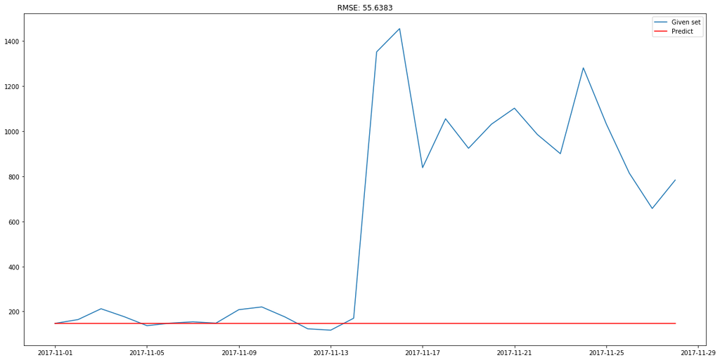

```
_______________________________________
Item: 26104
```

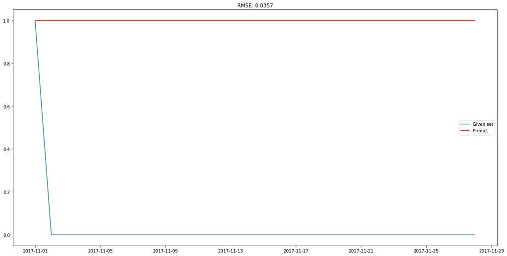

```
_______________________________________
Item: 158737
```

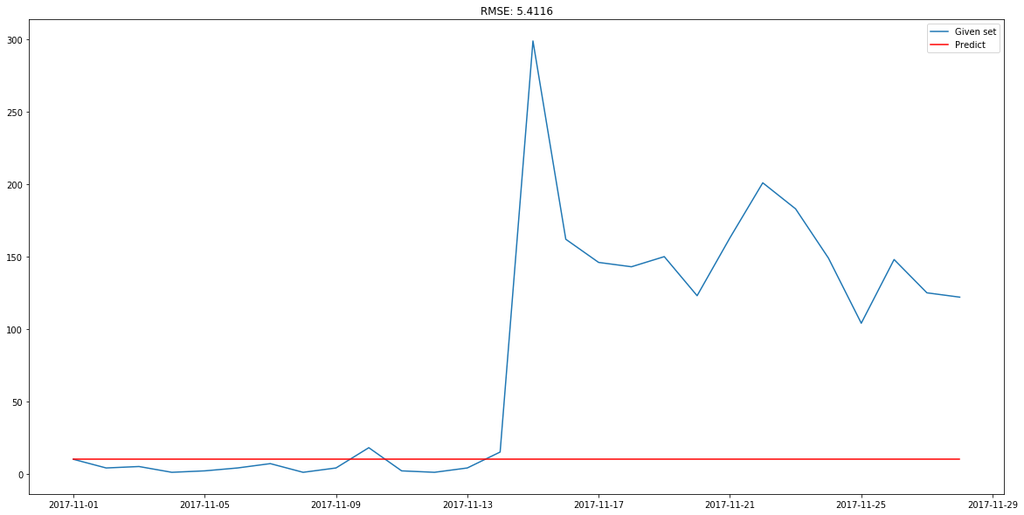

```
_______________________________________
Item: 158105
```

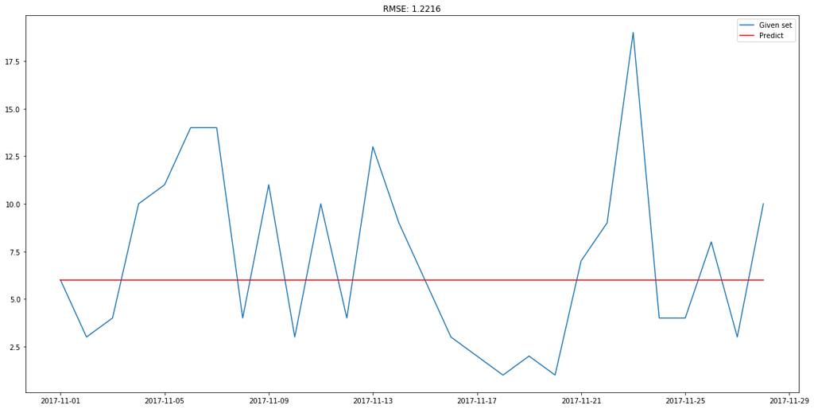

```python
for i in range(len(products)):

    print("_______________________________________")
    print("Item: "+str(products[i]))

    Train_df=Train[Train['product_id']==products[i]]
    valid_df=valid[valid['product_id']==products[i]]


    model = ARIMA(Train_df['volume_sold'].astype('float32').dropna(), order=(1, 0, 1))  # here the q value is zero since it is just the AR model
    results_ARIMA = model.fit(disp=-1)
    #train_log_diff = Train_log - Train_log.shift(1)
    #plt.plot(train_log_diff.dropna(), label='original')
    #plt.plot(results_ARIMA.fittedvalues, color='red', label='predictions')
    #plt.legend(loc='best')
    #plt.show()

    ARIMA_predict=results_ARIMA.predict(start="2017-11-01", end=28)

    check_prediction_diff(ARIMA_predict, valid_df)
```

# One forecast at time and adding predicted sales values from 2nd predictions

```
____________________________________________________________________________________________________

The RMSE of the ARIMA is 420.76471357226234
____________________________________________________________________________________________________

The MSE of the ARIMA  is 177042.94418754795
____________________________________________________________________________________________________

The MAE of the ARIMA  is 374.4606759981288
____________________________________________________________________________________________________

____________________________________________________________________________________________________

Sum of Original Sales for next 28 days:  16510.0
Sum of Predicted Sales for next 28 days:  [13759.73485805]
The difference between model original and predictions values of the ARIMA is [2750.26514195]
____________________________________________________________________________________________________
```

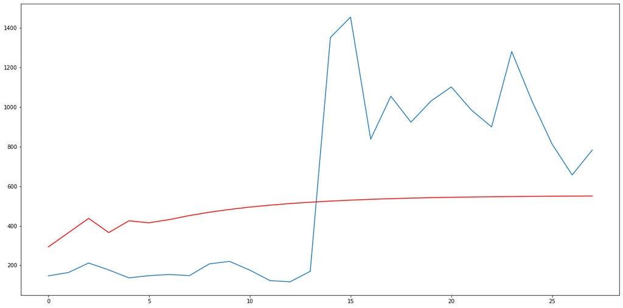

```python
Train_df=Train[Train['product_id']==13701]
valid_df=valid[valid['product_id']==13701]

history = [x for x in Train_df['volume_sold']]
history=np.array(history)
history = history.astype('float32')
history=list(history)

valid_df = [x for x in valid_df['volume_sold']]
valid_df=np.array(valid_df)
valid_df = valid_df.astype('float32')


predictions = list()

for t in range(len(valid_df)):
    model = ARIMA(history, order=(1,0,7))
    model_fit = model.fit(disp=0)
    output = model_fit.forecast()
    yhat = output[0]
    predictions.append(yhat)
    obs = valid_df[t]
    history.append(yhat)

model_quality(valid_df,predictions,"ARIMA")
# plot
pyplot.plot(valid_df,label="Original")
pyplot.plot(predictions, color='red',label="Predictions")
pyplot.show()
```

#### For all items, parameters are not tuned

```
_______________________________________
Item: 13701
```

```
____________________________________________________________________________________________________

The RMSE of the ARIMA is 660.3475774009464
____________________________________________________________________________________________________

The MSE of the ARIMA  is 436058.92297929886
____________________________________________________________________________________________________

The MAE of the ARIMA  is 481.65171257737114
____________________________________________________________________________________________________

____________________________________________________________________________________________________

Sum of Original Sales for next 28 days:  16510.0
Sum of Predicted Sales for next 28 days:  [3023.75204783]
The difference between model original and predictions values of the ARIMA is [13486.24795217]
____________________________________________________________________________________________________
```

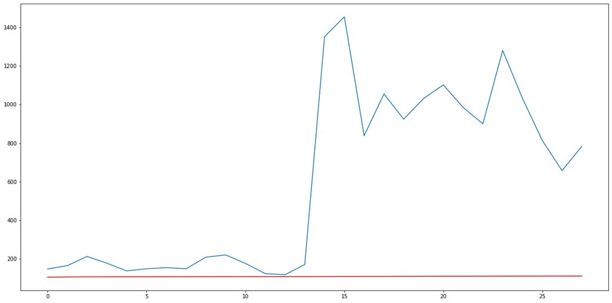

```
_______________________________________
Item: 26104
```

```
____________________________________________________________________________________________________

The RMSE of the ARIMA is 4.415115158836254
____________________________________________________________________________________________________

The MSE of the ARIMA  is 19.493241865785677
____________________________________________________________________________________________________

The MAE of the ARIMA  is 4.290100250125878
____________________________________________________________________________________________________

____________________________________________________________________________________________________

Sum of Original Sales for next 28 days:  1.0
Sum of Predicted Sales for next 28 days:  [121.122807]
The difference between model original and predictions values of the ARIMA is [-120.122807]
____________________________________________________________________________________________________
```

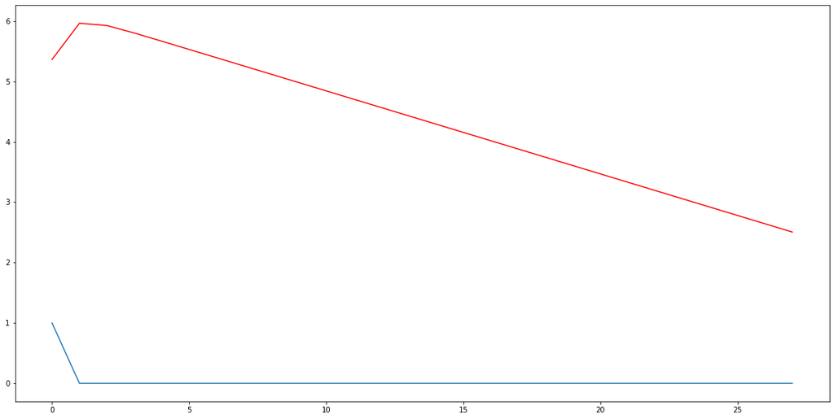

```
_______________________________________
Item: 158737
```

```
____________________________________________________________________________________________________

The RMSE of the ARIMA is 113.46667254064369
____________________________________________________________________________________________________

The MSE of the ARIMA  is 12874.685777445664
____________________________________________________________________________________________________

The MAE of the ARIMA  is 78.65237547574749
____________________________________________________________________________________________________

____________________________________________________________________________________________________

Sum of Original Sales for next 28 days:  2296.0
Sum of Predicted Sales for next 28 days:  [133.3043516]
The difference between model original and predictions values of the ARIMA is [2162.6956484]
____________________________________________________________________________________________________
```

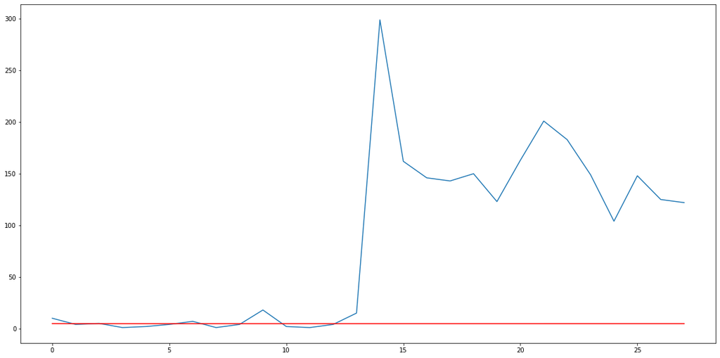

```
_______________________________________
Item: 158105
```

```
____________________________________________________________________________________________________

The RMSE of the ARIMA is 28.702073583272988
____________________________________________________________________________________________________

The MSE of the ARIMA  is 823.809027979617
____________________________________________________________________________________________________

The MAE of the ARIMA  is 28.312615845585434
____________________________________________________________________________________________________

____________________________________________________________________________________________________

Sum of Original Sales for next 28 days:  195.0
Sum of Predicted Sales for next 28 days:  [987.75324368]
The difference between model original and predictions values of the ARIMA is [-792.75324368]
____________________________________________________________________________________________________
```

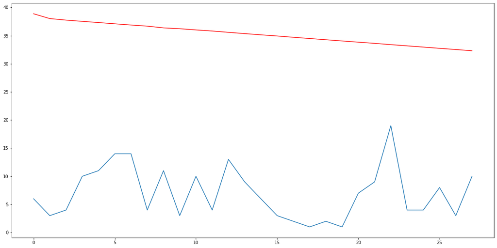

```python
for i in range(len(products)):

    print("_______________________________________")
    print("Item: "+str(products[i]))

    Train_df=Train[Train['product_id']==products[i]]
    valid_df=valid[valid['product_id']==products[i]]

    history = [x for x in Train_df['volume_sold']]
    history=np.array(history)
    history = history.astype('float32')
    history=list(history)

    valid_df = [x for x in valid_df['volume_sold']]
    valid_df=np.array(valid_df)
    valid_df = valid_df.astype('float32')


    predictions = list()

    for t in range(len(valid_df)):
        model = ARIMA(history, order=(1,1,1))
        model_fit = model.fit(disp=0)
        output = model_fit.forecast()
        yhat = output[0]
        predictions.append(yhat)
        obs = valid_df[t]
        history.append(yhat)

    model_quality(valid_df,predictions,"ARIMA")
    # plot
    pyplot.plot(valid_df,label="Original")
    pyplot.plot(predictions, color='red',label="Predictions")
    pyplot.show()
```

## ARIMAX Model

```python
for i in range(len(products)):

    print("_______________________________________")
    print("Item: "+str(products[i]))

    Train_df=Train[Train['product_id']==products[i]]
    valid_df=valid[valid['product_id']==products[i]]

    features_col=list(set(Train.columns.tolist())-set(["volume_sold","product_id","calendar_date","revenue","cost","stock_level","woy","vdm1","vwm1","vmm1","rdm1","rwm1","rmm1","cdm1","cwm1","cmm1","mpdm1","mpwm1","mpmm1"]))

    train_endo = [x for x in Train_df['volume_sold']]
    train_endo=np.array(train_endo)
    train_endo = train_endo.astype('float32')
    train_endo=list(train_endo)

    train_exo=Train_df[features_col].as_matrix()

    valid_endo = [x for x in valid_df['volume_sold']]
    valid_endo=np.array(valid_endo)
    valid_endo = valid_endo.astype('float32')

    valid_exo=valid_df[features_col].as_matrix()


    predictions = list()


    #for t in range(len(valid_exo)):

    model = SARIMAX(endog=train_endo,exog=train_exo, order=(1,1,1),seasonal_order=(0,0,0,0))
    model_fit = model.fit()
    #output = model_fit.predict(exog=valid_exo)

    #yhat = output[0]
    #predictions.append(yhat)
    #obs = valid_df[t]
    #history.append(yhat)
    #print(model_fit.summary())


    pred = model_fit.predict(exog = valid_exo)[:28]


    model_quality(valid_endo,pred,"ARIMAX")
```

```
_______________________________________
Item: 13701
```

```
____________________________________________________________________________________________________

The RMSE of the ARIMAX is 727.160678777668
____________________________________________________________________________________________________

The MSE of the ARIMAX  is 528762.6527603988
____________________________________________________________________________________________________

The MAE of the ARIMAX  is 590.2050742812426
____________________________________________________________________________________________________

____________________________________________________________________________________________________

Sum of Original Sales for next 28 days:  16510.0
Sum of Predicted Sales for next 28 days:  9960.243773033806
The difference between model original and predictions values of the ARIMAX is 6549.756226966194
____________________________________________________________________________________________________

_______________________________________
Item: 26104
```

```
____________________________________________________________________________________________________

The RMSE of the ARIMAX is 67.19678479772307
____________________________________________________________________________________________________

The MSE of the ARIMAX  is 4515.407887151507
____________________________________________________________________________________________________

The MAE of the ARIMAX  is 62.73697825986283
____________________________________________________________________________________________________

____________________________________________________________________________________________________

Sum of Original Sales for next 28 days:  1.0
Sum of Predicted Sales for next 28 days:  1531.8171963377006
The difference between model original and predictions values of the ARIMAX is -1530.8171963377006
____________________________________________________________________________________________________

_______________________________________
Item: 158737
____________________________________________________________________________________________________

The RMSE of the ARIMAX is 113.70085322410876
____________________________________________________________________________________________________

The MSE of the ARIMAX  is 12927.884023890321
____________________________________________________________________________________________________

The MAE of the ARIMAX  is 81.68674077933966
____________________________________________________________________________________________________

____________________________________________________________________________________________________

Sum of Original Sales for next 28 days:  2296.0
Sum of Predicted Sales for next 28 days:  454.1833248445638
The difference between model original and predictions values of the ARIMAX is 1841.8166751554363
____________________________________________________________________________________________________

_______________________________________
Item: 158105
```

```
____________________________________________________________________________________________________

The RMSE of the ARIMAX is 185.98156761885969
____________________________________________________________________________________________________

The MSE of the ARIMAX  is 34589.14349396848
____________________________________________________________________________________________________

The MAE of the ARIMAX  is 116.30136174153299
____________________________________________________________________________________________________

____________________________________________________________________________________________________

Sum of Original Sales for next 28 days:  195.0
Sum of Predicted Sales for next 28 days:  2127.5169329695527
The difference between model original and predictions values of the ARIMAX is -1932.5169329695527
____________________________________________________________________________________________________
```

### One forecast at time and adding original sales values from 2nd predictions (WRONG)

```
_______________________________________
Item: 13701
```

```
Test MSE: 76266.901
```

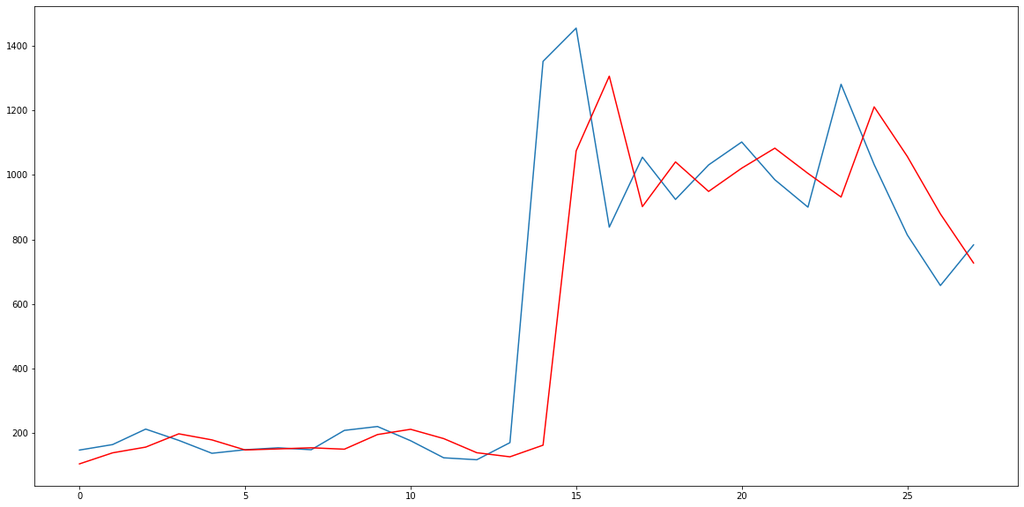

```
_______________________________________
Item: 26104
```

```
Test MSE: 2.425
```

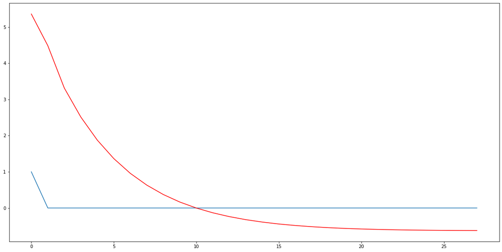

```
_______________________________________
Item: 158737
```

```
Test MSE: 3450.154
```

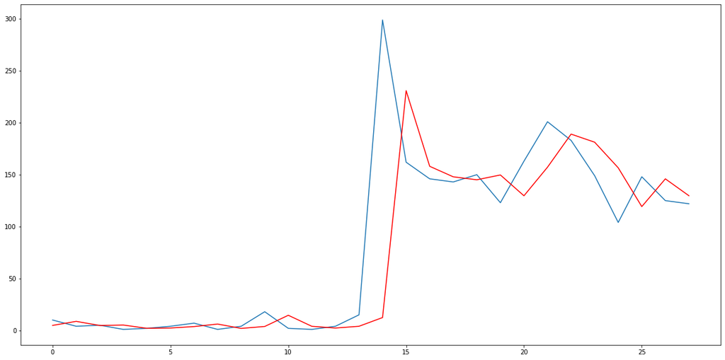

```
_______________________________________
Item: 158105
```

```
Test MSE: 568.619
```

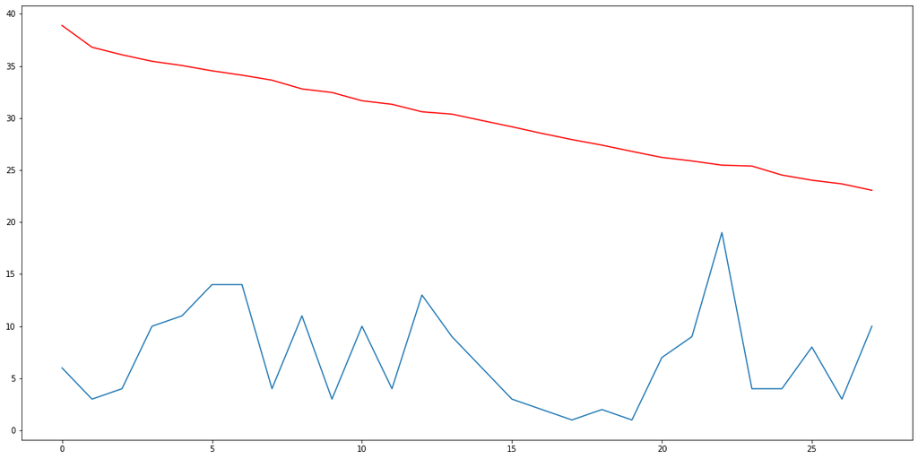

```python
for i in range(len(products)):

    print("_______________________________________")
    print("Item: "+str(products[i]))

    Train_df=Train[Train['product_id']==products[i]]
    valid_df=valid[valid['product_id']==products[i]]

    history = [x for x in Train_df['volume_sold']]
    history=np.array(history)
    history = history.astype('float32')
    history=list(history)

    valid_df = [x for x in valid_df['volume_sold']]
    valid_df=np.array(valid_df)
    valid_df = valid_df.astype('float32')


    predictions = list()

    for t in range(len(valid_df)):
        model = ARIMA(history, order=(1,1,1))
        model_fit = model.fit(disp=0)
        output = model_fit.forecast()
        yhat = output[0]
        predictions.append(yhat)
        obs = valid_df[t]
        history.append(obs)
        #print('predicted=%f, expected=%f' % (yhat, obs))

    error = mean_squared_error(valid_df, predictions)
    print('Test MSE: %.3f' % error)
    # plot
    pyplot.plot(valid_df)
    pyplot.plot(predictions, color='red')
    pyplot.show()
```